# Kansas School District Expenditures Per Pupil

Earl F Glynn

2022-10-14

# 1 Setup

## 1.1

## 1.2 Constants

```r
FILE_PREFIX   <- "Expenditures-Per-Pupil"    # no spaces
```

Percentiles: 0% (min), 10%, 25%, 50% (median), 75%, 90%, 100% (max)

```r
quantiles <- quantiles <- c(0.0, 0.10, 0.25, 0.50, 0.75, 0.90, 1.00)
```

```r
SOURCE <- "Source:  KSDE Data Central - School Finance Reports"
stamp  <- paste("watchdoglab.substack.com  efg", format(Sys.time(), "%Y-%m-%d"))
```

```r
EXCEL_LIMIT <- 2^20
```

## 1.3 Packages

```r
library(tidyverse)
```

```r
library(lubridate)
```

Display formatting

```r
library(kableExtra)  # kable_styling
```

```r
#library(IRdisplay)   # display_html (needed in Jupyter notebooks)
```

I/O

```r
library(readxl)      # read_xlsx
library(readr)       # write_csv
library(writexl)     # write_xlsx
```

Graphics

```r
library(scales)      # comma, comma_format
```

## 1.4 ggplot theme

[ggplot Themes Gallery](https://www.datanovia.com/en/blog/ggplot-themes-gallery/)

```r
theme_set(theme_minimal() +

          theme(axis.text             = element_text(size = 10),
                axis.title            = element_text(size = 14),

                plot.caption          = element_text(hjust = c(0.0,1.0)),
                plot.caption.position = "plot",   # R 4.0.0

                plot.title.position   = "plot",
                plot.title            = element_text(size = 13))
           )
```

```r
COLOR_BAR     <- "skyblue"
COLOR_OUTLINE <- "grey80"
```

## 1.5 Helper functions

```r
Show <- function(data, caption="", bigMark="",
                 height = NULL, width = NULL, ...)
{
  data                                       %>%
  kable("html", caption=caption,
        format.args=list(big.mark=bigMark))  %>%
  kable_styling(bootstrap_options=c("striped", "bordered", "condensed"),
                position="left",
                full_width=FALSE, ...)       %>%
  scroll_box(height = height, width = width)#%>%      # pixels
# as.character()                             %>%      # Jupyter Only
# display_html()                                      # Jupyter Only
}
```

Redundant checks to verify the data format and content is the same across all files.

row index is zero origin

```r
processHeader <- function(filename)
{
  header <- read_xls(filename, n_max = 5, col_names = FALSE)

  SchoolYear <- str_sub(filename, 24, 32)

  heading    <- header[1, 1, drop = TRUE]

  ColumnSchoolYear <- header[4, 4, drop = TRUE]

  USD        <- header[5, 1, drop = TRUE]
  County     <- header[5, 3, drop = TRUE]
  FTE        <- header[5, 4, drop = TRUE]
  PerPupil   <- header[5, 5, drop = TRUE]

  tibble(File = filename, SchoolYear = SchoolYear,
         ColumnSchoolYear,
         heading = heading, USD, County, FTE, PerPupil)
}
```

Assign column names here since files have school year in most columns and we need common columns names across all files.

```r
processYear <- function(filename)
{
  districts <-
    read_xls(filename, skip = 5, col_names = FALSE) %>%
    rename(
            USD              = ...1,
            `USD Name`       = ...2,
            County           = ...3,
            `FTE Enroll`     = ...4,
            `Capital Outlay` = ...5,
            `Bond Interest`  = ...6,
            `All Others`     = ...7,
            `Total Expend`   = ...8
          )                                         %>%
    filter(!is.na(USD))   %>%   # remove blank line before TOTALS line
    mutate(SchoolYear = str_sub(filename, 24, 32))  %>%
    relocate(SchoolYear)

  districts
}
```

Create separate “wide” files for various fields in combined file

```r
ExtractFieldWide <- function(field)
{
  districtsYears                               %>%
  select(SchoolYear, USD, `USD Name`, County,
         District, {{field}})                  %>%
  pivot_wider(names_from   = SchoolYear,
              values_from  = {{field}})        %>%
  arrange(USD)
}
```

```r
SetupPlotDensity <- function(districtsYears, field, name,
                             schoolYear = "2020-2021")
{
  plotSetup <-
    districtsYears                        %>%
    filter(startsWith(USD, "D"),                # Exclude totals
           SchoolYear == schoolYear)      %>%

    ggplot(aes(x = {{field}}, y = ..density..))                         +
      geom_histogram(fill = "skyblue", colour = "grey80", bins = 20)    +
      geom_density()                                                    +
      scale_x_continuous(labels = scales::label_dollar())               +
      labs(
            title      = paste0("Kansas School Districts - ", name,
                                " Per Pupil"),
            subtitle   = paste(schoolYear, "school year"),
            x          = paste0(name, " Per Pupil [$]"),
            y         = "Density",
            caption = c(SOURCE, stamp)
          )                             +
      theme(
             panel.grid.minor.x = element_blank(),
             panel.grid.minor.y = element_blank(),
             plot.caption  = element_text(hjust=c(0.0, 1.0))
           )

  plotSetup
}
```

# 2 Extract from Excel Files

## 2.1 Data Source

1. Start on this page: [Kansas Department of Education Data Central](https://datacentral.ksde.org/)
2. School Finance Reports / [School Finance Reports Warehouse](https://datacentral.ksde.org/school_finance_reports.aspx)
3. Selections
- Report format: Excel
- Report: Expenditures Per Pupil

*Shows the Total Expenditures per Pupil for each district, and state totals, as well as expenditures per pupil for the Capital Outlay Fund, Bond & Interest Fund and All Other Funds combined.*

Details in [Expenditures Per Pupil](https://www.ksde.org/Portals/0/School%20Finance/reports_and_publications/Expenditures/Expend%20Per%20Pupil%20Cover%2C%20State%20Totals.pdf) Report [11 pages]

- School Year: 2007-2008 through 2020-2021
- Display Report
4. Save to Excel file: Expenditures-Per-Pupil-yyyy-yyyy.xls

## 2.2 Create list of Excel files

```r
 files <-
  list.files(path = ".", pattern = glob2rx("Expenditures-Per-Pupil-*.xls"))

length(files)
```

```
[1] 14
```

```r
files
```

```
 [1] "Expenditures-Per-Pupil-2007-2008.xls"
 [2] "Expenditures-Per-Pupil-2008-2009.xls"
 [3] "Expenditures-Per-Pupil-2009-2010.xls"
 [4] "Expenditures-Per-Pupil-2010-2011.xls"
 [5] "Expenditures-Per-Pupil-2011-2012.xls"
 [6] "Expenditures-Per-Pupil-2012-2013.xls"
 [7] "Expenditures-Per-Pupil-2013-2014.xls"
 [8] "Expenditures-Per-Pupil-2014-2015.xls"
 [9] "Expenditures-Per-Pupil-2015-2016.xls"
[10] "Expenditures-Per-Pupil-2016-2017.xls"
[11] "Expenditures-Per-Pupil-2017-2018.xls"
[12] "Expenditures-Per-Pupil-2018-2019.xls"
[13] "Expenditures-Per-Pupil-2019-2020.xls"
[14] "Expenditures-Per-Pupil-2020-2021.xls"
```

## 2.3 Process Headers

Verify `File` names and `SchoolYear` values in header are consistent.

```r
headerInfo <-
  files  %>%
  map_df(processHeader)
```

```r
dim(headerInfo)
```

```
[1] 14  8
```

Make sure heading is the same for all files.

```r
headerInfo %>% Show(height = "200px")
```

| File | SchoolYear | ColumnSchoolYear | heading | USD | County | FTE | PerPupil |
| --- | --- | --- | --- | --- | --- | --- | --- |
| Expenditures-Per-Pupil-2007-2008.xls | 2007-2008 | 2007-08 | USD Expenditures Per Pupil | USD | County Name | FTE Enroll | Per Pupil |
| Expenditures-Per-Pupil-2008-2009.xls | 2008-2009 | 2008-09 | USD Expenditures Per Pupil | USD | County Name | FTE Enroll | Per Pupil |
| Expenditures-Per-Pupil-2009-2010.xls | 2009-2010 | 2009-10 | USD Expenditures Per Pupil | USD | County Name | FTE Enroll | Per Pupil |
| Expenditures-Per-Pupil-2010-2011.xls | 2010-2011 | 2010-11 | USD Expenditures Per Pupil | USD | County Name | FTE Enroll | Per Pupil |
| Expenditures-Per-Pupil-2011-2012.xls | 2011-2012 | 2011-12 | USD Expenditures Per Pupil | USD | County Name | FTE Enroll | Per Pupil |
| Expenditures-Per-Pupil-2012-2013.xls | 2012-2013 | 2012-13 | USD Expenditures Per Pupil | USD | County Name | FTE Enroll | Per Pupil |
| Expenditures-Per-Pupil-2013-2014.xls | 2013-2014 | 2013-14 | USD Expenditures Per Pupil | USD | County Name | FTE Enroll | Per Pupil |
| Expenditures-Per-Pupil-2014-2015.xls | 2014-2015 | 2014-15 | USD Expenditures Per Pupil | USD | County Name | FTE Enroll | Per Pupil |
| Expenditures-Per-Pupil-2015-2016.xls | 2015-2016 | 2015-16 | USD Expenditures Per Pupil | USD | County Name | FTE Enroll | Per Pupil |
| Expenditures-Per-Pupil-2016-2017.xls | 2016-2017 | 2016-17 | USD Expenditures Per Pupil | USD | County Name | FTE Enroll | Per Pupil |
| Expenditures-Per-Pupil-2017-2018.xls | 2017-2018 | 2017-18 | USD Expenditures Per Pupil | USD | County Name | FTE Enroll | Per Pupil |
| Expenditures-Per-Pupil-2018-2019.xls | 2018-2019 | 2018-19 | USD Expenditures Per Pupil | USD | County Name | FTE Enroll | Per Pupil |
| Expenditures-Per-Pupil-2019-2020.xls | 2019-2020 | 2019-20 | USD Expenditures Per Pupil | USD | County Name | FTE Enroll | Per Pupil |
| Expenditures-Per-Pupil-2020-2021.xls | 2020-2021 | 2020-21 | USD Expenditures Per Pupil | USD | County Name | FTE Enroll | Per Pupil |

```r
all( (paste0(str_sub(headerInfo$SchoolYear, 1, 5), str_sub(headerInfo$SchoolYear, 8, 9)) ==
      headerInfo$ColumnSchoolYear) %>% as.vector() )
```

```
[1] TRUE
```

```r
all( (headerInfo$heading == "USD Expenditures Per Pupil") %>% as.vector() )
```

```
[1] TRUE
```

```r
all( (headerInfo$USD == "USD") %>% as.vector() )
```

```
[1] TRUE
```

```r
all( (headerInfo$County == "County Name") %>% as.vector() )
```

```
[1] TRUE
```

```r
all( (headerInfo$FTE == "FTE Enroll") %>% as.vector() )
```

```
[1] TRUE
```

```r
all( (headerInfo$PerPupil == "Per Pupil") %>% as.vector() )
```

```
[1] TRUE
```

With `TRUE` for all the above checks, let’s assume we can assign column names to replace the ones in the files with school year in several columns.

## 2.4 Process USD data

```r
districtsYears <-
  files  %>%
  map_dfr(processYear)
```

```r
dim(districtsYears)
```

```
[1] 4031    9
```

```r
glimpse(districtsYears)
```

```
Rows: 4,031
Columns: 9
$ SchoolYear       <chr> "2007-2008", "2007-2008", "2007-2008", "2007-2008", "…
$ USD              <chr> "D0101", "D0102", "D0103", "D0105", "D0106", "D0107",…
$ `USD Name`       <chr> "Erie-Galesburg", "Cimarron-Ensign", "Cheylin", "Rawl…
$ County           <chr> "Neosho", "Gray", "Cheyenne", "Rawlins", "Ness", "Jew…
$ `FTE Enroll`     <dbl> 571.7, 653.5, 143.0, 309.0, 171.0, 266.5, 414.5, 507.…
$ `Capital Outlay` <dbl> 823.69250, 837.93114, 370.01399, 1475.43689, 898.7193…
$ `Bond Interest`  <dbl> 0.0000, 672.8523, 0.0000, 0.0000, 354.3158, 173.6923,…
$ `All Others`     <dbl> 15300.094, 9749.114, 14451.678, 12558.861, 15031.135,…
$ `Total Expend`   <dbl> 16123.787, 11259.897, 14821.692, 14034.298, 16284.170…
```

## 2.5 Sample data

Recall USD Names are not unique. `Blue Valley` school district is in both Johnson and Riley counties.

```r
districtsYears  %>%  head(3)  %>%  Show(bigMark = ",")
```

| SchoolYear | USD | USD Name | County | FTE Enroll | Capital Outlay | Bond Interest | All Others | Total Expend |
| --- | --- | --- | --- | --- | --- | --- | --- | --- |
| 2007-2008 | D0101 | Erie-Galesburg | Neosho | 571.7 | 823.6925 | 0.0000 | 15,300.094 | 16,123.79 |
| 2007-2008 | D0102 | Cimarron-Ensign | Gray | 653.5 | 837.9311 | 672.8523 | 9,749.114 | 11,259.90 |
| 2007-2008 | D0103 | Cheylin | Cheyenne | 143.0 | 370.0140 | 0.0000 | 14,451.678 | 14,821.69 |

Let’s combine `USD Name` and `County` into single `District` field, which will be unique.

```r
districtsYears <-
  districtsYears    %>%
  mutate(District = paste0(`USD Name`, " [", County, "]") )
```

```r
districtsYears  %>%  head(3)  %>%  Show(bigMark = ",")
```

| SchoolYear | USD | USD Name | County | FTE Enroll | Capital Outlay | Bond Interest | All Others | Total Expend | District |
| --- | --- | --- | --- | --- | --- | --- | --- | --- | --- |
| 2007-2008 | D0101 | Erie-Galesburg | Neosho | 571.7 | 823.6925 | 0.0000 | 15,300.094 | 16,123.79 | Erie-Galesburg [Neosho] |
| 2007-2008 | D0102 | Cimarron-Ensign | Gray | 653.5 | 837.9311 | 672.8523 | 9,749.114 | 11,259.90 | Cimarron-Ensign [Gray] |
| 2007-2008 | D0103 | Cheylin | Cheyenne | 143.0 | 370.0140 | 0.0000 | 14,451.678 | 14,821.69 | Cheylin [Cheyenne] |

## 2.6 Write combined raw data to file

### 2.6.1 Long Format

```r
write_xlsx(districtsYears,
           paste0(FILE_PREFIX, "-by-School-District-LongFormat.xlsx"))
```

## 2.7 Summary stats

```r
districtsYears           %>%
  summarize(
             n           = n(),
             nSchoolYear = n_distinct(SchoolYear),
             nUSD        = n_distinct(USD),
             nUSDname    = n_distinct(`USD Name`),
             nCounty     = n_distinct(County),
             nDistrict   = n_distinct(District)
           )             %>%
  Show()
```

| n | nSchoolYear | nUSD | nUSDname | nCounty | nDistrict |
| --- | --- | --- | --- | --- | --- |
| 4031 | 14 | 301 | 300 | 106 | 301 |

# 3 Full-Time Equivalent (FTE) Enrollment

## 3.1 Data

```r
FTEWide  <- ExtractFieldWide(`FTE Enroll`)
nrow(FTEWide)
```

```
[1] 301
```

Sample data

```r
FTEWide  %>%  head(3)  %>%  Show(caption = "FTE Enrollment")
```

FTE Enrollment

| USD | USD Name | County | District | 2007-2008 | 2008-2009 | 2009-2010 | 2010-2011 | 2011-2012 | 2012-2013 | 2013-2014 | 2014-2015 | 2015-2016 | 2016-2017 | 2017-2018 | 2018-2019 | 2019-2020 | 2020-2021 |
| --- | --- | --- | --- | --- | --- | --- | --- | --- | --- | --- | --- | --- | --- | --- | --- | --- | --- |
| D0101 | Erie-Galesburg | Neosho | Erie-Galesburg [Neosho] | 571.7 | 547.3 | 508.5 | 518.6 | 505.5 | 526.6 | 515 | 535.5 | 513.5 | 503.0 | 521.5 | 491.5 | 471.0 | 424.5 |
| D0102 | Cimarron-Ensign | Gray | Cimarron-Ensign [Gray] | 653.5 | 650.0 | 658.7 | 670.8 | 675.7 | 655.7 | 653 | 642.8 | 625.0 | 626.0 | 644.7 | 667.6 | 661.9 | 637.5 |
| D0103 | Cheylin | Cheyenne | Cheylin [Cheyenne] | 143.0 | 130.5 | 137.0 | 138.0 | 138.5 | 121.5 | 127 | 137.0 | 133.5 | 122.5 | 128.5 | 126.5 | 143.0 | 144.0 |

```r
write_xlsx(FTEWide, "FTE-Enrollment-by-School-District-WideFormat.xlsx")
```

## 3.2 Density Plot - Latest Year

Shows FTE distribution across the state, which is quite broad

Override some defaults used in other plots

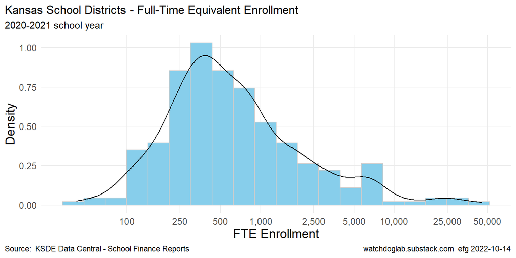

```r
SetupPlotDensity(districtsYears, `FTE Enroll`,  "")     +
  scale_x_log10(breaks = c(   100,   250,   500,           # override default
                               1000,  2500,  5000,
                              10000, 25000, 50000,
                             1000000),
                  labels = comma)                       +
    labs(title = "Kansas School Districts - Full-Time Equivalent Enrollment",
         x = "FTE Enrollment")
```

# 4 Expenditures Per Pupil

## 4.1 Capital Outlay

### 4.1.1 Data

```r
CapitalOutlayExpendPerPupilWide  <- ExtractFieldWide(`Capital Outlay`)
nrow(CapitalOutlayExpendPerPupilWide)
```

```
[1] 301
```

Sample data

```r
CapitalOutlayExpendPerPupilWide  %>%  head(3)  %>%  Show(caption = "Capital Outlay Expenditures Per Pupil")
```

Capital Outlay Expenditures Per Pupil

| USD | USD Name | County | District | 2007-2008 | 2008-2009 | 2009-2010 | 2010-2011 | 2011-2012 | 2012-2013 | 2013-2014 | 2014-2015 | 2015-2016 | 2016-2017 | 2017-2018 | 2018-2019 | 2019-2020 | 2020-2021 |
| --- | --- | --- | --- | --- | --- | --- | --- | --- | --- | --- | --- | --- | --- | --- | --- | --- | --- |
| D0101 | Erie-Galesburg | Neosho | Erie-Galesburg [Neosho] | 823.6925 | 88.18016 | 1490.9951 | 1909.8033 | 2020.7240 | 373.0422 | 542.3903 | 500.2969 | 542.9114 | 611.4394 | 580.7018 | 836.7650 | 1398.826 | 471.0224 |
| D0102 | Cimarron-Ensign | Gray | Cimarron-Ensign [Gray] | 837.9311 | 265.51077 | 155.1237 | 990.5575 | 568.3425 | 374.5310 | 621.9832 | 127.2495 | 360.7008 | 303.5495 | 1151.9901 | 378.6249 | 167.829 | 717.8651 |
| D0103 | Cheylin | Cheyenne | Cheylin [Cheyenne] | 370.0140 | 882.26820 | 935.0511 | 1283.4638 | 949.0830 | 610.4938 | 1005.7638 | 2052.8978 | 1691.5880 | 2196.5224 | 1124.5370 | 1588.2609 | 3067.629 | 1626.6736 |

```r
write_xlsx(CapitalOutlayExpendPerPupilWide,
           paste0(FILE_PREFIX, "-by-School-District-CapitalOutlay-Expenditures-WideFormat.xlsx"))
```

### 4.1.2 Density Plot - Latest Year

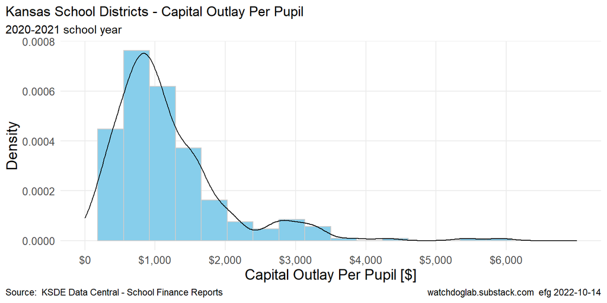

```r
options(scipen = 999)
SetupPlotDensity(districtsYears, `Capital Outlay`, "Capital Outlay")  +
   scale_x_continuous(labels = scales::label_dollar(),
                      breaks = 1000 * 0:6,
                      limits = c(0, 7000))
```

## 4.2 Bond Interest

### 4.2.1 Data

```r
BondInterestExpendPerPupilWide  <- ExtractFieldWide(`Bond Interest`)
nrow(BondInterestExpendPerPupilWide)
```

```
[1] 301
```

Sample data

```r
BondInterestExpendPerPupilWide  %>%  head(3)  %>%  Show(caption = "Bond Interest Expenditures Per Pupil")
```

Bond Interest Expenditures Per Pupil

| USD | USD Name | County | District | 2007-2008 | 2008-2009 | 2009-2010 | 2010-2011 | 2011-2012 | 2012-2013 | 2013-2014 | 2014-2015 | 2015-2016 | 2016-2017 | 2017-2018 | 2018-2019 | 2019-2020 | 2020-2021 |
| --- | --- | --- | --- | --- | --- | --- | --- | --- | --- | --- | --- | --- | --- | --- | --- | --- | --- |
| D0101 | Erie-Galesburg | Neosho | Erie-Galesburg [Neosho] | 0.0000 | 1084.272 | 1369.719 | 2437.0343 | 2642.0673 | 2767.5940 | 2835.6485 | 2721.841 | 2592.1363 | 2957.2982 | 2731.8849 | 2890.0163 | 2897.8875 | 3317.8163 |
| D0102 | Cimarron-Ensign | Gray | Cimarron-Ensign [Gray] | 672.8523 | 668.980 | 1019.394 | 588.8566 | 563.7753 | 738.8409 | 493.9127 | 498.561 | 563.3152 | 588.6038 | 572.2289 | 560.5392 | 573.0715 | 675.6376 |
| D0103 | Cheylin | Cheyenne | Cheylin [Cheyenne] | 0.0000 | 0.000 | 0.000 | 0.0000 | 0.0000 | 0.0000 | 0.0000 | 0.000 | 0.0000 | 0.0000 | 0.0000 | 0.0000 | 0.0000 | 0.0000 |

```r
write_xlsx(BondInterestExpendPerPupilWide,
           paste0(FILE_PREFIX, "-by-School-District-BondInterest-Expenditures-WideFormat.xlsx"))
```

### 4.2.2 Density Plot - Latest Year

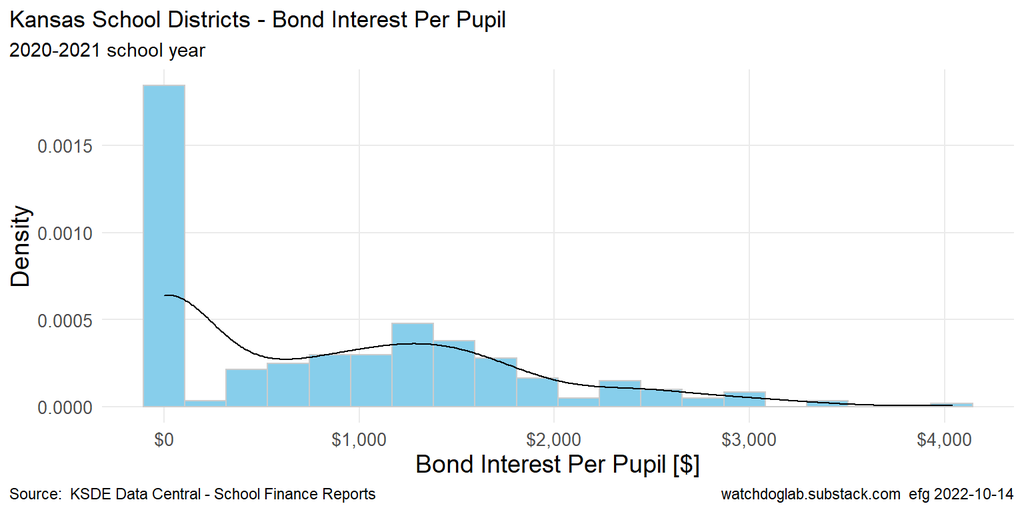

```r
SetupPlotDensity(districtsYears, `Bond Interest`, "Bond Interest")
```

## 4.3 All Others

### 4.3.1 Data

```r
AllOthersExpendPerPupilWide  <- ExtractFieldWide(`All Others`)
nrow(AllOthersExpendPerPupilWide)
```

```
[1] 301
```

Sample data

```r
AllOthersExpendPerPupilWide  %>%  head(3)  %>%  Show(caption = "All Others Expenditures Per Pupil")
```

All Others Expenditures Per Pupil

| USD | USD Name | County | District | 2007-2008 | 2008-2009 | 2009-2010 | 2010-2011 | 2011-2012 | 2012-2013 | 2013-2014 | 2014-2015 | 2015-2016 | 2016-2017 | 2017-2018 | 2018-2019 | 2019-2020 | 2020-2021 |
| --- | --- | --- | --- | --- | --- | --- | --- | --- | --- | --- | --- | --- | --- | --- | --- | --- | --- |
| D0101 | Erie-Galesburg | Neosho | Erie-Galesburg [Neosho] | 15300.094 | 13806.77 | 13125.691 | 12864.107 | 13599.64 | 13011.90 | 13951.76 | 13260.38 | 13899.89 | 14005.68 | 13641.45 | 13586.26 | 14340.14 | 15646.38 |
| D0102 | Cimarron-Ensign | Gray | Cimarron-Ensign [Gray] | 9749.114 | 10472.76 | 9856.429 | 9416.935 | 10053.89 | 10909.53 | 12366.45 | 11438.92 | 11026.93 | 11625.07 | 11643.11 | 11931.70 | 14099.32 | 15289.87 |
| D0103 | Cheylin | Cheyenne | Cheylin [Cheyenne] | 14451.678 | 15951.51 | 15969.285 | 15848.239 | 16225.90 | 18665.59 | 17708.92 | 16135.42 | 15807.60 | 17186.69 | 16940.96 | 18026.80 | 16785.62 | 18133.07 |

```r
write_xlsx(AllOthersExpendPerPupilWide,
           paste0(FILE_PREFIX, "-by-School-District-AllOthers-Expenditures-WideFormat.xlsx"))
```

### 4.3.2 Density Plot - Latest Year

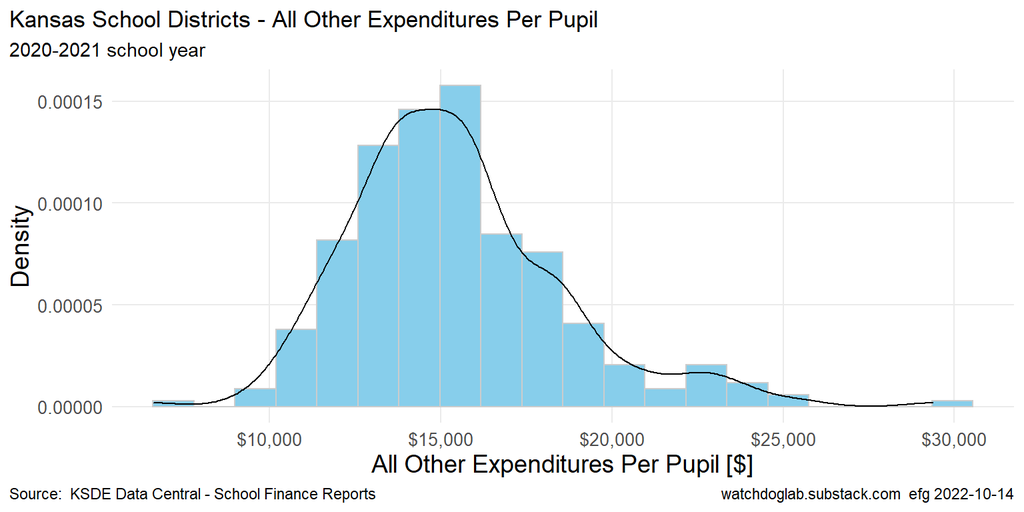

```r
SetupPlotDensity(districtsYears, `All Others`, "All Other Expenditures")
```

## 4.4 Total Expenditures

### 4.4.1 Data

```r
TotalExpendPerPupilWide  <- ExtractFieldWide(`Total Expend`)
nrow(TotalExpendPerPupilWide)
```

```
[1] 301
```

```r
TotalExpendPerPupilWide  %>%  head(3)  %>%  Show(caption = "Total Expenditures Per Pupil")
```

Total Expenditures Per Pupil

| USD | USD Name | County | District | 2007-2008 | 2008-2009 | 2009-2010 | 2010-2011 | 2011-2012 | 2012-2013 | 2013-2014 | 2014-2015 | 2015-2016 | 2016-2017 | 2017-2018 | 2018-2019 | 2019-2020 | 2020-2021 |
| --- | --- | --- | --- | --- | --- | --- | --- | --- | --- | --- | --- | --- | --- | --- | --- | --- | --- |
| D0101 | Erie-Galesburg | Neosho | Erie-Galesburg [Neosho] | 16123.79 | 14979.22 | 15986.41 | 17210.94 | 18262.43 | 16152.53 | 17329.80 | 16482.52 | 17034.93 | 17574.42 | 16954.04 | 17313.04 | 18636.86 | 19435.22 |
| D0102 | Cimarron-Ensign | Gray | Cimarron-Ensign [Gray] | 11259.90 | 11407.25 | 11030.95 | 10996.35 | 11186.01 | 12022.91 | 13482.35 | 12064.73 | 11950.94 | 12517.22 | 13367.33 | 12870.87 | 14840.22 | 16683.38 |
| D0103 | Cheylin | Cheyenne | Cheylin [Cheyenne] | 14821.69 | 16833.78 | 16904.34 | 17131.70 | 17174.98 | 19276.08 | 18714.69 | 18188.32 | 17499.18 | 19383.21 | 18065.49 | 19615.06 | 19853.25 | 19759.74 |

```r
write_xlsx(TotalExpendPerPupilWide,
           paste0(FILE_PREFIX, "-by-School-District-Total-Expenditures-WideFormat.xlsx"))
```

### 4.4.2 Density Plot - Latest Year

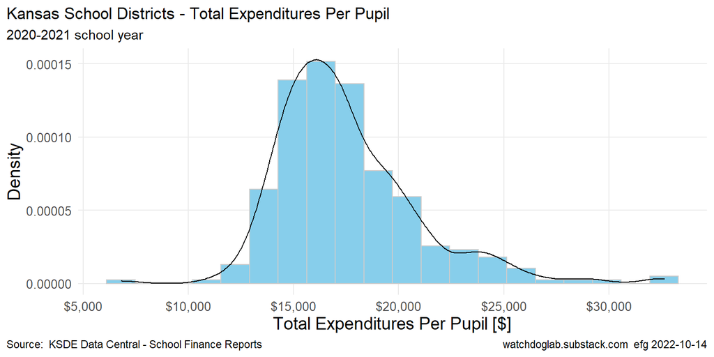

```r
SetupPlotDensity(districtsYears, `Total Expend`, "Total Expenditures")
```

# 5 State Summary by School Year

```r
yearSummary <-
  districtsYears  %>%
  filter(USD == "TOTALS") %>%
  select(SchoolYear, `FTE Enroll`, `Total Expend`)  %>%
  mutate(
          MidYear   = ymd( paste0( str_sub(SchoolYear, 6, 9), "-01-01"))
        )           %>%
  relocate(MidYear)

dim(yearSummary)
```

```
[1] 14  4
```

```r
yearSummary %>% Show(bigMark = ",")
```

| MidYear | SchoolYear | FTE Enroll | Total Expend |
| --- | --- | --- | --- |
| 2008-01-01 | 2007-2008 | 446,596.0 | 12,183.63 |
| 2009-01-01 | 2008-2009 | 447,237.7 | 12,656.78 |
| 2010-01-01 | 2009-2010 | 450,774.6 | 12,329.64 |
| 2011-01-01 | 2010-2011 | 453,981.9 | 12,284.89 |
| 2012-01-01 | 2011-2012 | 456,000.5 | 12,652.90 |
| 2013-01-01 | 2012-2013 | 457,896.6 | 12,775.74 |
| 2014-01-01 | 2013-2014 | 461,088.3 | 12,959.60 |
| 2015-01-01 | 2014-2015 | 463,266.4 | 13,124.19 |
| 2016-01-01 | 2015-2016 | 463,167.7 | 13,016.71 |
| 2017-01-01 | 2016-2017 | 460,095.6 | 13,224.60 |
| 2018-01-01 | 2017-2018 | 476,672.6 | 13,619.86 |
| 2019-01-01 | 2018-2019 | 476,481.7 | 14,084.59 |
| 2020-01-01 | 2019-2020 | 476,454.3 | 14,848.15 |
| 2021-01-01 | 2020-2021 | 462,543.2 | 15,867.31 |

```r
write_xlsx(yearSummary %>% select(-MidYear),
           paste0(FILE_PREFIX, "-Total-Expenditures-Summary-by-School-Year.xlsx"))
```

## 5.1 Governor information

```r
governor <-
  tibble(
          Name = c("Sebelius", "Parkinson", "Brownback",
                   "Colyer", "Kelly"),

          TermStart = ymd("2007-07-01",  # for plotting purposes
                          "2009-04-28", "2011-01-10",
                          "2018-01-31", "2019-01-14"),

          TermEnd   = ymd("2009-04-28", "2011-01-10", "2018-01-31",
                          "2019-01-14",
                          "2021-12-31"),   # for plotting purposes,

          fraction1  = c(1.00, 0.93, 1.00, 0.93, 1.00),
          fraction2  = c(1.00, 0.60, 1.00, 0.60, 1.00),

          Party      = c("D", "D", "R", "R", "D")
        )

Brownback <- governor %>% filter(Name == "Brownback")
```

## 5.2 FTE State Summary by Year

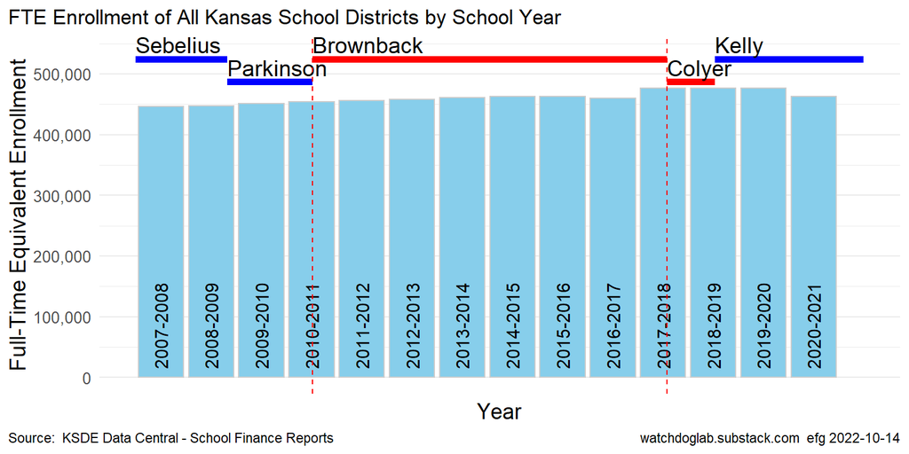

```r
ggplot(data = yearSummary) +
  geom_col(aes(x = MidYear, y = `FTE Enroll`),
           fill = "skyblue", colour = "grey80") +
  labs(title    = paste("FTE Enrollment of All Kansas School Districts",
                        "by School Year"),
       x = "Year",
       y = "Full-Time Equivalent Enrollment",
       caption = c(SOURCE, stamp))              +
  scale_y_continuous(labels = scales::comma,
                     breaks = 100000 * 0:5)     +
  theme(axis.text.x = element_blank(),
        panel.grid.major.x = element_blank(),
        panel.grid.minor.x = element_blank(),
        legend.position = "none")               +
  geom_text(data = yearSummary,
            aes(x = MidYear, y = 0,
                label = SchoolYear),
                vjust = 0.5, hjust = -0.1, size = 4, angle = 90)   +
  geom_segment(data = governor,
               aes(x = TermStart,  y    =  fraction1 * max(yearSummary$`FTE Enroll`) * 1.1,
               xend = TermEnd,     yend =  fraction1 * max(yearSummary$`FTE Enroll`) * 1.1,
               color = Party), size = 2)        +
  geom_text(data = governor,
            aes(x = TermStart, y =  1.02 * fraction1 * max(yearSummary$`FTE Enroll`) * 1.1,
                label = Name),
                vjust = 0.0, hjust = 0, size = 5)  +
  scale_color_manual(values = c("D" = "blue", "R" = "red"))  +
  geom_vline(xintercept = c(Brownback$TermStart, Brownback$TermEnd),
             color = "red", linetype = "dashed")
```

## 5.3 Total Expenditures per Pupil

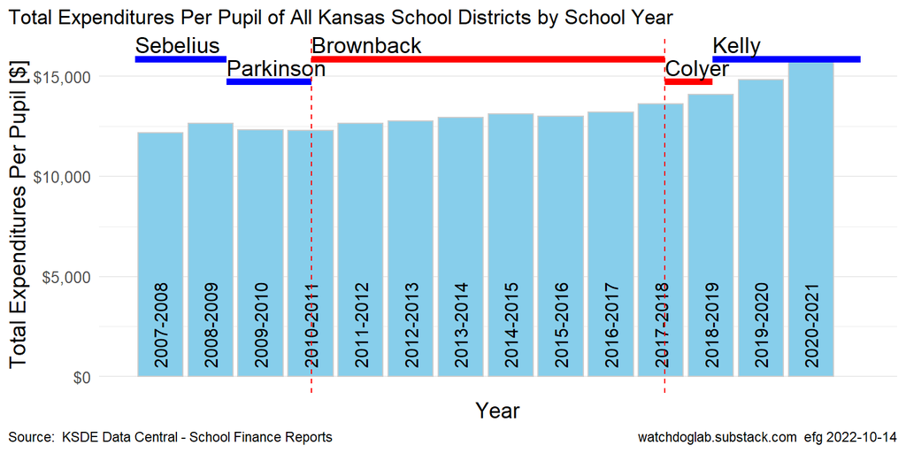

```r
ggplot(data = yearSummary) +
  geom_col(aes(x = MidYear, y = `Total Expend`),
           fill = "skyblue", colour = "grey80") +
  labs(title    = paste("Total Expenditures Per Pupil of All Kansas School Districts",
                        "by School Year"),
       x = "Year",
       y = "Total Expenditures Per Pupil [$]",
       caption = c(SOURCE, stamp))              +
   scale_y_continuous(labels = scales::label_dollar())            +
  theme(axis.text.x = element_blank(),
        panel.grid.major.x = element_blank(),
        panel.grid.minor.x = element_blank(),
        legend.position = "none")               +
  geom_text(data = yearSummary,
            aes(x = MidYear, y = 0,
                label = SchoolYear),
                vjust = 0.5, hjust = -0.1, size = 4, angle = 90)  +
  geom_segment(data = governor,
               aes(x = TermStart,  y    =  fraction1 * max(yearSummary$`Total Expend`),
               xend = TermEnd,     yend =  fraction1 * max(yearSummary$`Total Expend`),
               color = Party), size = 2)        +
  geom_text(data = governor,
            aes(x = TermStart, y =  1.02 * fraction1 * max(yearSummary$`Total Expend`),
                label = Name),
                vjust = 0.0, hjust = 0, size = 5)  +
  scale_color_manual(values = c("D" = "blue", "R" = "red"))  +
  geom_vline(xintercept = c(Brownback$TermStart, Brownback$TermEnd),
             color = "red", linetype = "dashed")
```

## 5.4 Total Expenditures per Pupil With Breakdown

```r
yearSummaryBreakdown <-
  districtsYears    %>%
  filter(USD == "TOTALS")                        %>%
  select(-USD, -`USD Name`, -County, -District)  %>%
  mutate(
          MidYear   = ymd( paste0( str_sub(SchoolYear, 6, 9), "-01-01"))
        )           %>%
  relocate(MidYear)

dim(yearSummaryBreakdown)
```

```
[1] 14  7
```

```r
yearSummaryBreakdown %>% Show(bigMark = ",")
```

| MidYear | SchoolYear | FTE Enroll | Capital Outlay | Bond Interest | All Others | Total Expend |
| --- | --- | --- | --- | --- | --- | --- |
| 2008-01-01 | 2007-2008 | 446,596.0 | 601.4567 | 776.8997 | 10,805.28 | 12,183.63 |
| 2009-01-01 | 2008-2009 | 447,237.7 | 700.2400 | 816.1928 | 11,140.35 | 12,656.78 |
| 2010-01-01 | 2009-2010 | 450,774.6 | 650.7137 | 907.3249 | 10,771.60 | 12,329.64 |
| 2011-01-01 | 2010-2011 | 453,981.9 | 570.3471 | 968.6558 | 10,745.88 | 12,284.89 |
| 2012-01-01 | 2011-2012 | 456,000.5 | 652.1617 | 988.1676 | 11,012.57 | 12,652.90 |
| 2013-01-01 | 2012-2013 | 457,896.6 | 632.0313 | 1,025.6437 | 11,118.06 | 12,775.74 |
| 2014-01-01 | 2013-2014 | 461,088.3 | 633.9321 | 1,014.3429 | 11,311.32 | 12,959.60 |
| 2015-01-01 | 2014-2015 | 463,266.4 | 815.0644 | 1,062.9627 | 11,246.17 | 13,124.19 |
| 2016-01-01 | 2015-2016 | 463,167.7 | 765.0245 | 1,223.7198 | 11,027.96 | 13,016.71 |
| 2017-01-01 | 2016-2017 | 460,095.6 | 793.5838 | 1,219.3295 | 11,211.68 | 13,224.60 |
| 2018-01-01 | 2017-2018 | 476,672.6 | 861.2962 | 1,192.3464 | 11,566.21 | 13,619.86 |
| 2019-01-01 | 2018-2019 | 476,481.7 | 958.0674 | 1,328.7698 | 11,797.75 | 14,084.59 |
| 2020-01-01 | 2019-2020 | 476,454.3 | 961.9526 | 1,320.6743 | 12,565.52 | 14,848.15 |
| 2021-01-01 | 2020-2021 | 462,543.2 | 1,124.6393 | 1,371.6200 | 13,371.05 | 15,867.31 |

```r
write_xlsx(yearSummaryBreakdown %>% select(-MidYear),
           paste0(FILE_PREFIX, "-Total-Expenditures-Summary-Breakdown-by-School-Year.xlsx"))
```

```r
yearSummaryBreakdownLong <-
  yearSummaryBreakdown    %>%
  pivot_longer(
                cols      = c(`Capital Outlay`, `Bond Interest`, `All Others`),
                names_to  = "Fund",
                values_to = "Amount"
              )           %>%
  arrange(SchoolYear, Fund)
```

```r
PALETTE <- "Set2"   # Qualitative palette
```

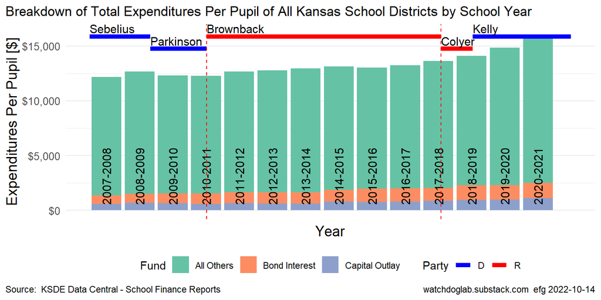

```r
ggplot(data = yearSummaryBreakdownLong)                 +
  geom_col(aes(x = MidYear, y = Amount, fill = Fund))   +
  labs(title    = paste("Breakdown of Total Expenditures Per Pupil of All Kansas School Districts",
                        "by School Year"),
       x = "Year",
       y = "Expenditures Per Pupil [$]",
       caption = c(SOURCE, stamp))                      +
  scale_fill_brewer(palette = PALETTE)                  +      # Qualitative palette
  scale_y_continuous(labels = scales::label_dollar())   +
  theme(axis.text.x = element_blank(),
        panel.grid.major.x = element_blank(),
        panel.grid.minor.x = element_blank(),
        legend.position = "bottom")                     +
  geom_text(data = yearSummary,
            aes(x = MidYear, y = 0,
                label = SchoolYear),
                vjust = 0.5, hjust = -0.1, size = 4, angle = 90)  +
  geom_segment(data = governor,
               aes(x = TermStart,  y    =  fraction1 * max(yearSummary$`Total Expend`),
               xend = TermEnd,     yend =  fraction1 * max(yearSummary$`Total Expend`),
               color = Party), size = 2)                +
  geom_text(data = governor,
            aes(x = TermStart, y =  1.02 * fraction1 * max(yearSummary$`Total Expend`),
                label = Name),
                vjust = 0.0, hjust = 0, size = 4)       +
  scale_color_manual(values = c("D" = "blue", "R" = "red"))  +
  geom_vline(xintercept = c(Brownback$TermStart, Brownback$TermEnd),
             color = "red", linetype = "dashed")
```

# 6 Epilog

## 6.1

Processing time: 8.1 secs

2022-10-14 2238